# HW 06 - Iterating functions on Chicago cold

# Learning goals

- Write a function in an R script and load it using `source()`
- Iterate a function over multiple data structures

## Data

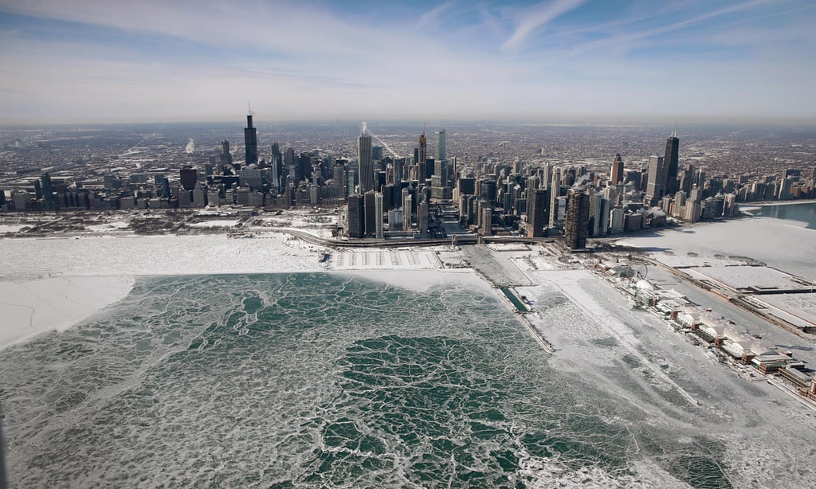

Chicago temperatures - February 2021

We will be working with data downloaded from [Weather Underground](https://www.wunderground.com/) for three stations:

- The Loop - `chicago-loop.csv`
- Southloop - `chicago-south-loop.csv`
- Oak Park - `chicago-oak-park.csv`

Each dataset has daily min, average, and max temperatures for each day in February 2021. This was one of the coldest and snowiest Februarys in recent Chicago history!

## Packages

We will need `{dplyr}` and `{purrr}` package functions from the tidyverse, and date functions from `lubridate`.

```r
library(tidyverse)
library(lubridate)
```

## Warm up

Before we introduce the data, let’s warm up with some simple exercises.

- Update the YAML, changing the author name to your name, and **knit** the document.
- Commit your changes with a meaningful commit message.
- Push your changes to GitHub.

## Importing the function

Below is the code we used to create the `convert_temperature()` function. Do **not** copy it into the homework 6 starter file. Instead, we are going to save our function code in an R script.

```r
convert_temperature <- function(temperature_vector){

  celcius <- (temperature_vector - 32) * (5/9)
  kelvin <- celcius + 273.15

  tibble("fahrenheit" = temperature_vector,
         "celcius" = celcius,
         "kelvin" = kelvin)

}
```

```r
source("convert_temperatures.R")
```

🧶 ✅ ⬆️ Knit, *commit, and push your changes to GitHub with an appropriate commit message.*

It is standard practice in R to keep the underlying code for your functions separate from the main RMarkdown file you work within for a project. We just created an R script containing the code for `convert_temperature()` and saved it with the name `convert_temperatures.R`. When we run the function `source("convert_temperatures.R")`, R executes the code in that R script in our RMarkdown environment and, as a result, creates the function object `convert_temperature()`.

2. Just as as sanity-check, let’s test out the function we just imported. Insert a new labeled code chunk below Exercise 2 in your starter file. Write a single line of code that will test your function with the single Fahrenheit value = `32`.

## Importing and recoding the data

3. Look at the 3 `.csv` files in your starter directory `/data` folder. Insert a labeled code chunk under Exercise 3 in your starter file that imports each of the three datasets and assigns them to object names of your choice. Remember, you cannot use hyphens (`-`) in object names, but you can use underscores (`_`)! Add a second labeled chunk below the first, that gives you a glimpse of each dataset.
4. Notice that the `date` column is still as data type `character string`. Copy the first code chunk from Exercise 3, that you used to **import** the data, into Exercise 4 in your starter file. Import the data again, and over-write the same objects, but this time, pass the `col_types` argument within `read_csv()` a vector of `col_type()` functions to correctly read the first column as dates. Remember you will need to change your chunk label. **Then** add a second labeled chunk below the first, that gives you a glimpse of each dataset to confirm that they now have the correct `date` column data type.

If you are struggling with the col_type argument, you can check the syntax in Week 9 slides on Blackboard `importing and recoding data`.

## Wrangling and merging the data

5. Copy the code chunk below into Exercise 5 in your starter file. Complete it so that each data set is changed in the following ways: 1) `mutate()` is used to create a new column called `neighborhood`; 2) `relocate()` is used to move the new column to the first column position; 3) then, in the fourth pipeline, each data set is joined using `bind_rows()` to create a new data frame object called `chicago_temperatures`. Remember to change `eval = T`.

```r
loop <- loop %>%
  mutate(neighborhood = "loop") %>%
  relocate(___)

south_loop <- south_loop %>%
  mutate(neighborhood = "___") %>%
  ___(neighborhood)

oak_park <- oak_park %>%
  mutate(___ = "___") %>%
  ___(___)

___ <- loop %>%
  bind_rows(south_loop) %>%
  bind_rows(oak_park)
```

## Iterate the conversion function

`map()` iterates functions over elements in a list, however, our data is currently in a data frame.

8. Copy and complete the code chunk below into Exercise 8 in your starter file. Complete it to create a list of length 3 from the 3 temperature columns in the `chicago_temperatures` data frame object. Remember to change `eval = T`.

```r
chicago_temperatures_list <- ___(chicago_temperatures$temperature_high,
                                  ___$temperature_avg,
                                  ___$temperature_low)
```

9. Write and label a code chunk under Exercise 9 in your starter file that will apply the `convert_temperature()` function to each vector element in your new list object and will combine output together **by row** into a dataframe. (Hint: check the slide or help page on `map()` functions if you’re not sure). Assign your output to `chicago_temperatures_converted`.
10. Copy and complete the code below into Exercise 10 of your starter file. Once completed, the code should rejoin the converted temperature data frame to the first two columns of the original `chicago_temperatures` data frame (i.e. `neighborhood` and `date`). Remember to change `eval = T`.

```r
___ %>%
    pivot_longer(
    names_to = "measurement",
    values_to = "fahrenheit",
    cols = 3:5
  ) %>%
  select(___, ___) %>%
  bind_cols(chicago_temperatures_converted)
```

Great work! We just worked through applying our own custom function to a list object. This was an improvement over copying and pasting the function multiple times. Moreover, knowing how to write your own functions is a valuable R programming skill! However, remember that we could have completed this temperature conversion more quickly using tidy data and tidyverse functions. Below is an example of a tidyverse pipeline we could have used.

```r
chicago_temperatures %>%
  pivot_longer(
    names_to = "measurement",
    values_to = "fahrenheit",
    cols = 3:5
  ) %>%
  mutate(celcius = (fahrenheit - 32) * (5/9),
         kelvin  = celcius + 273.15)
```

You are finished with Homework 6! 🧶 ✅ ⬆️ Knit, *commit, and push your changes to GitHub with an appropriate commit message.*